# White-browedcoucals gradients

2025-10-08

```r
set.seed(123)
```

# White-browed coucals Bateman Gradients

This script models the reproductive and mating success of white-browed coucals through generalized mixed effect models. It aims to obtain the Bateman gradient of females (n=83) based on data collected over 13 breeding seasons. The study focused on white-browed coucals inhabiting the Usangu wetlands of Tanzania.

The first model estimates the gradient of females with absolute values, the second with standardized values. Each model also calculates 95% credible intervals for effect sizes and sex intercepts and slopes.

We also provide the calculations to obtain the sex and category-specific opportunities for selection and sexual selection.

```r
#Load libraries
library(MASS)
library(ggplot2)# Visualising results
library(dplyr)
library(ggpubr) #to arrange two plots in one figure
library(arm) # Bayesian analysis
library(tidyverse)
library(gridExtra)
library(lme4) # to run the mixed model
library(arm) # bayesian analysis
library(blmeco) # check checking for over dispersion in the models
library(cowplot)
library(ggtext)
library(grid)
library(gt)
# Set the working directory
#knitr::opts_knit$set(root.dir = "setwd(getwd())")

# Read the CSV file
dataclean <- read.csv("data/Whitebrowedcoucals_gradients.csv")
```

```r
#Set a theme for plots
# Define a custom theme
custom_theme <- theme_bw() +
  theme(text = element_text(family = "Arial"),
        legend.text = element_text(size = 8),
        legend.title = element_text(size = 8),
        axis.text = element_text(size = 10),
        axis.title = element_text(size = 10),
        title = element_text(size=10),
        plot.title = element_text(size = 13, face = "bold"),  # bold title
        legend.key.size = unit(0.4, "cm") ,
        axis.title.y = element_markdown())
```

# Description of structure of the data

```r
# Assigning factors to variables
dataclean <- dataclean %>%
  mutate(
    lab_id = as.factor(lab_id),
    year = as.factor(year),
    no_off = as.numeric(no_off),
    no_mates = as.numeric(no_mates),
    sex = as.factor(sex),
    random_factor = as.integer(random_factor)
  )
```

```r
#Subsetting data of females and males
fe<-dataclean %>% filter(sex=="female") %>% droplevels()
#fe$random_factor <- as.factor(1:nrow(fe))
head(fe)
```

|  | lab_id | year | no_off | no_mates | sex | random_factor | ring_no |
| --- | --- | --- | --- | --- | --- | --- | --- |
| 1 | CM05_037 | 2005 | 3 | 1 | female | 1 | GN 44454 |
| 2 | CM05_051 | 2005 | 4 | 1 | female | 2 | GN 44462 |
| 3 | CM05_067 | 2005 | 6 | 1 | female | 3 | NA |
| 4 | CM05_072 | 2005 | 2 | 1 | female | 4 | GN 44483 |
| 5 | CM05_117 | 2005 | 4 | 1 | female | 5 | GN 52387 |
| 6 | CW13_046 | 2006 | 2 | 1 | female | 6 | NA |

```r
ma<-dataclean %>% filter(sex=="male") %>% droplevels()
#ma$random_factor <- as.factor(1:nrow(ma))
head(ma)
```

|  | lab_id | year | no_off | no_mates | sex | random_factor | ring_no |
| --- | --- | --- | --- | --- | --- | --- | --- |
| 1 | CM05_009 | 2005 | 2 | 1 | male | 103 | GN 44429 |
| 2 | CM05_018 | 2005 | 6 | 1 | male | 104 | GN 44441 |
| 3 | CM05_026 | 2005 | 4 | 1 | male | 105 | GN 44447 |
| 4 | CM05_028 | 2005 | 4 | 1 | male | 106 | GN 44450 |
| 5 | CM05_033 | 2005 | 4 | 1 | male | 107 | GN 44453 |
| 6 | CM05_038 | 2005 | 3 | 1 | male | 108 | GN 44455 |

```r
# Count the number of unique females
num_unique_females <- dataclean %>%
  filter(sex == "female") %>%
  summarize(num_females = n_distinct(lab_id))

# Display the result
print(num_unique_females) #83
```

```
##   num_females
## 1          83
```

```r
#Count the number of unique males
num_unique_males <- dataclean %>%
  filter(sex == "male") %>%
  summarize(num_unique_males = n_distinct(lab_id))

# Display the result
print(num_unique_males) #79
```

```
##   num_unique_males
## 1               79
```

```r
# Find the rows with duplicated values in the "parent" column
duplicated_rows <- dataclean[duplicated(dataclean$lab_id) | duplicated(dataclean$lab_id, fromLast = TRUE), ]

# Print the result
head(duplicated_rows)
```

|  | lab_id | year | no_off | no_mates | sex | random_factor | ring_no |
| --- | --- | --- | --- | --- | --- | --- | --- |
| 8 | CW13_255 | 2010 | 4 | 1 | female | 8 | GN 56768 |
| 9 | CW13_255 | 2011 | 4 | 1 | female | 9 | GN 56768 |
| 10 | CW13_256 | 2010 | 5 | 1 | female | 10 | GN 56781 |
| 11 | CW13_256 | 2011 | 8 | 1 | female | 11 | GN 56781 |
| 18 | CW13_397 | 2010 | 8 | 1 | female | 18 | GN 56828 |
| 19 | CW13_397 | 2011 | 9 | 1 | female | 19 | GN 56828 |

```r
# Count the number of unique values in the "lab_id" column with duplicated values
unique_parent_count <- duplicated_rows %>%
  summarize(unique_parents = n_distinct(lab_id))

# Print the result
print(unique_parent_count) #35 individuals with multiple entries in years
```

```
##   unique_parents
## 1             35
```

```r
# Select the unique values in the "parent" column
unique_parents <- duplicated_rows %>%
  distinct(lab_id)

# Print the result (i.e shows the individuals with multiple entries across years)
print(unique_parents)
```

```
##      lab_id
## 1  CW13_255
## 2  CW13_256
## 3  CW13_397
## 4  CW13_529
## 5  CW13_606
## 6  CW13_607
## 7  CW13_616
## 8  CW15_046
## 9  CW15_053
## 10 CW15_059
## 11 CW16_244
## 12 CW16_255
## 13 CW16_257
## 14 CW16_273
```

[output cut: 21 more lines]

```r
histoff<- ggplot(dataclean, aes(x = no_off)) +
  geom_histogram(binwidth = 1, fill = "white", color = "black") +
  labs(title = "Frequency offspring per year", x = "Values", y = "Frequency") +
  theme_bw()

 # Count the total number of no_off values
total_no_off <- dataclean %>%
  summarize(total_no_off = sum(no_off))

# Print the result
print(total_no_off) #986
```

```
##   total_no_off
## 1          986
```

```r
# data across years
levels(dataclean$year) # "2005" "2006" "2008" "2010" "2011" "2012" "2013" "2014" "2015" "2016" "2017" "2018" "2019"
```

```
##  [1] "2005" "2006" "2008" "2010" "2011" "2012" "2013" "2014" "2015" "2016"
## [11] "2017" "2018" "2019"
```

```r
#13 years

# Count the number of individuals with repeated measures
num_individuals_repeated <- dataclean %>%
  group_by(lab_id, sex,) %>%
  summarize(num_measures = n_distinct(year))
# Filter for individuals with more than one measure
num_individuals_repeated <- num_individuals_repeated %>%
  filter(num_measures > 1)

# Print the result
print(num_individuals_repeated, n= Inf) #35 individuals
```

```
## # A tibble: 35 × 3
## # Groups:   lab_id [35]
##    lab_id   sex    num_measures
##    <fct>    <fct>         <int>
##  1 CW13_237 male              3
##  2 CW13_238 male              3
##  3 CW13_239 male              2
##  4 CW13_255 female            2
##  5 CW13_256 female            2
##  6 CW13_385 male              3
##  7 CW13_397 female            2
##  8 CW13_399 male              4
##  9 CW13_528 male              2
## 10 CW13_529 female            3
## 11 CW13_605 male              2
```

[output cut: 24 more lines]

```r
table(num_individuals_repeated$sex) #16 females, 19 males
```

```
##
## female   male
##     16     19
```

```r
#Example
dataclean %>% filter(lab_id == "CW13_255")
```

| lab_id | year | no_off | no_mates | sex | random_factor | ring_no |
| --- | --- | --- | --- | --- | --- | --- |
| CW13_255 | 2010 | 4 | 1 | female | 8 | GN 56768 |
| CW13_255 | 2011 | 4 | 1 | female | 9 | GN 56768 |

```r
table(fe$sex)
```

```
##
## female
##    102
```

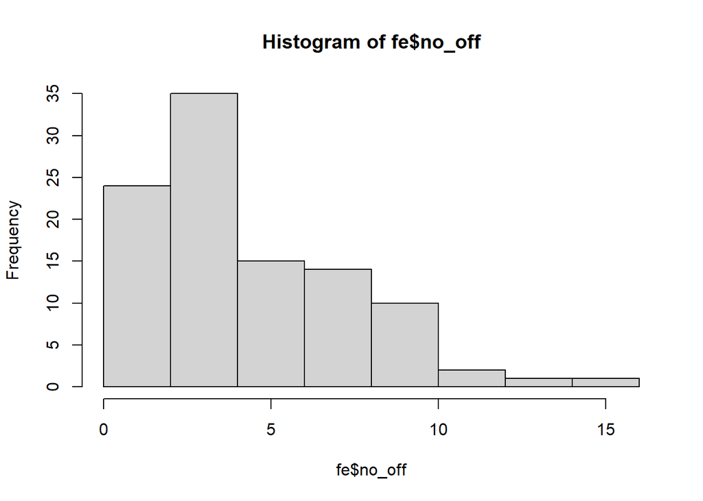

```r
#Visualising the response variables by sex

hist(fe$no_off)
```

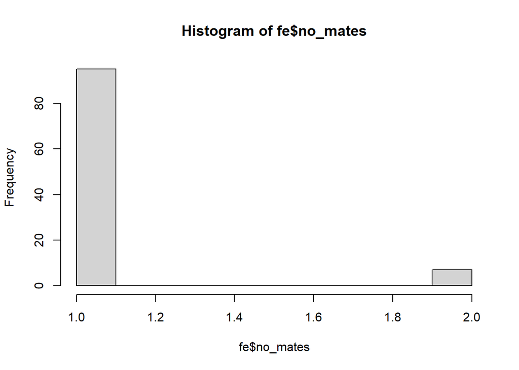

```r
hist(fe$no_mates)
```

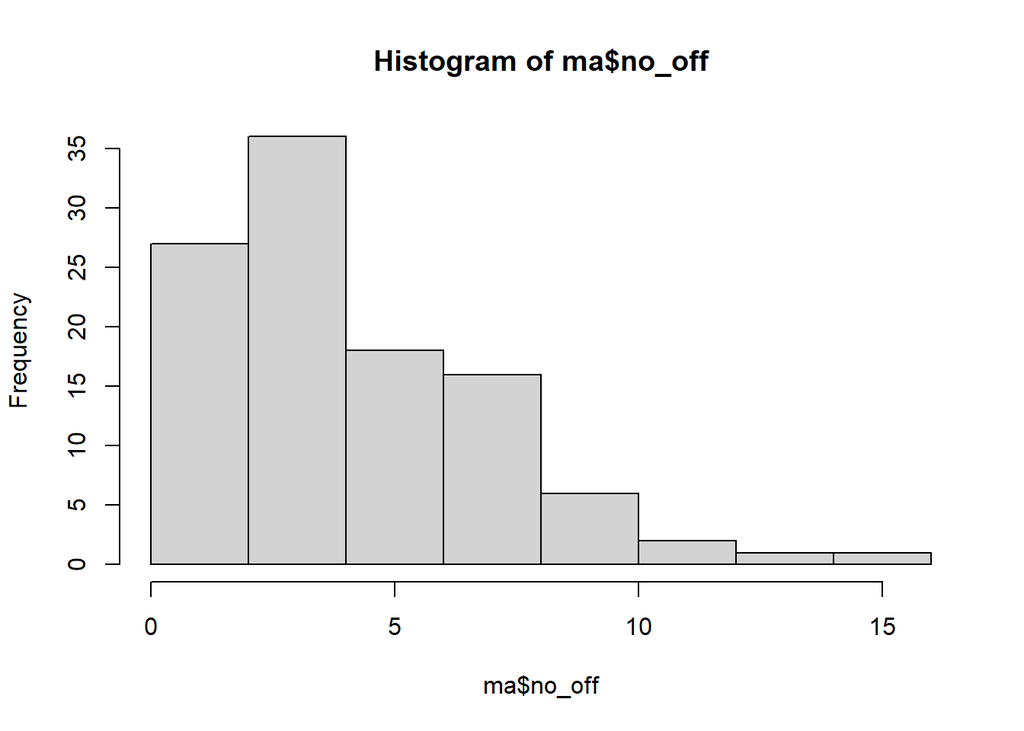

```r
hist(ma$no_off)
```

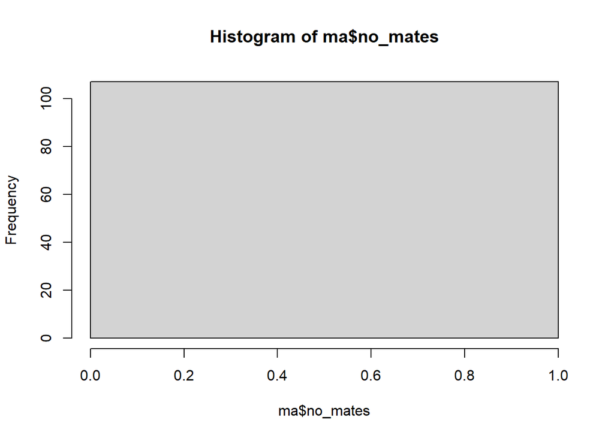

```r
hist(ma$no_mates)
```

#Scaling reproductive and mating success

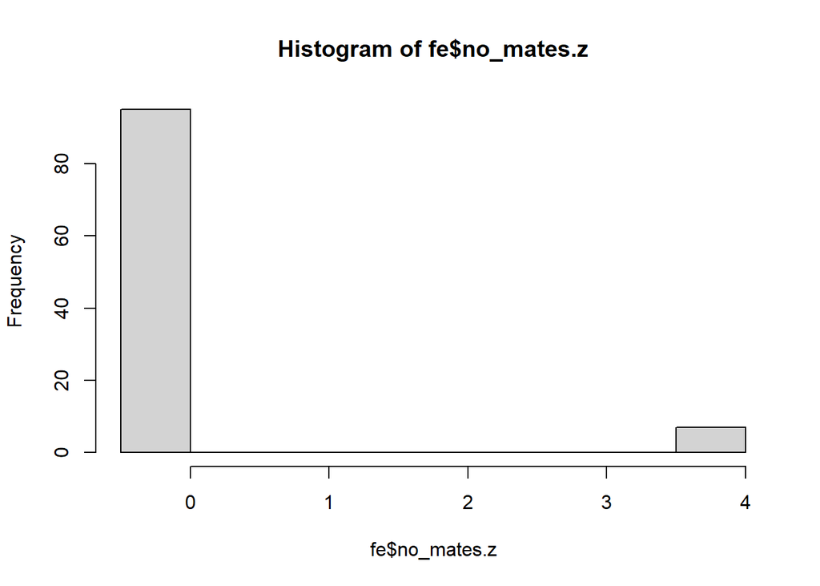

```r
fe$no_mates.z <-scale(fe$no_mates)
hist(fe$no_mates.z)
```

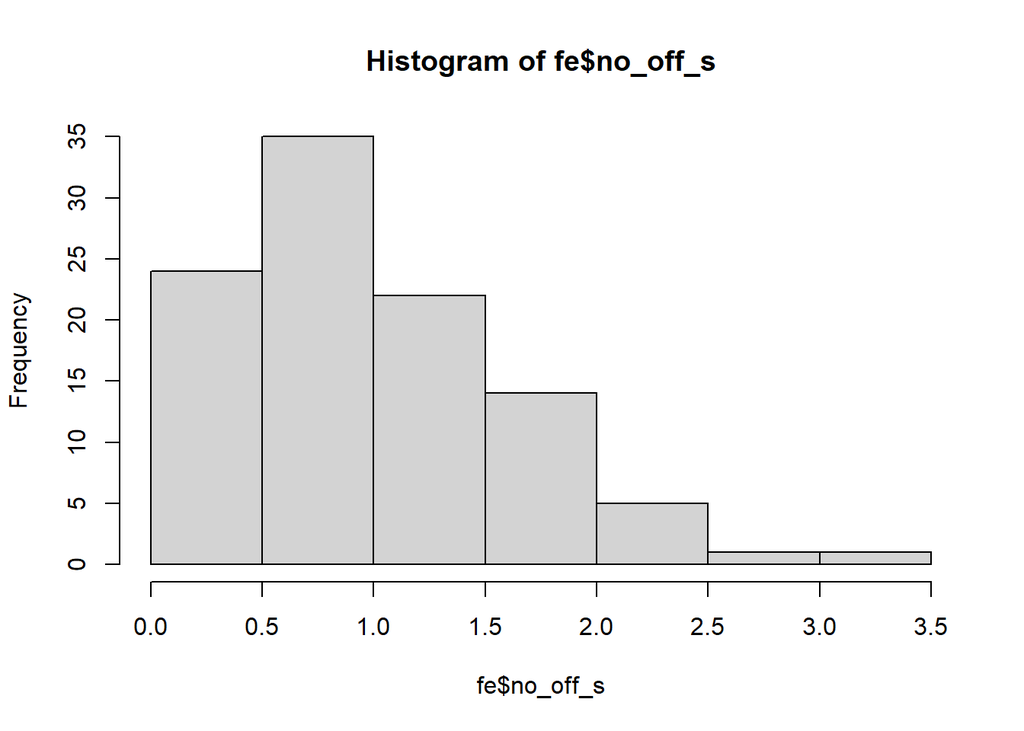

```r
fe$no_off_s <- fe$no_off/ mean(fe$no_off)
hist(fe$no_off_s)
```

```r
fe <- fe %>%
  mutate(
    no_mates.z = no_mates / mean(no_mates),
    no_off_s  = no_off / mean(no_off)
  )

ma$no_off_s <- ma$no_off/ mean(ma$no_off)
mean(ma$no_off_s)
```

```
## [1] 1
```

```r
ma$no_mates.z <- 1


# Display the head of the 'fe' and 'ma' dataframes
head(fe)
```

|  | lab_id | year | no_off | no_mates | sex | random_factor | ring_no | no_mates.z | no_off_s |
| --- | --- | --- | --- | --- | --- | --- | --- | --- | --- |
| 1 | CM05_037 | 2005 | 3 | 1 | female | 1 | GN 44454 | 0.9357798 | 0.6206897 |
| 2 | CM05_051 | 2005 | 4 | 1 | female | 2 | GN 44462 | 0.9357798 | 0.8275862 |
| 3 | CM05_067 | 2005 | 6 | 1 | female | 3 | NA | 0.9357798 | 1.2413793 |
| 4 | CM05_072 | 2005 | 2 | 1 | female | 4 | GN 44483 | 0.9357798 | 0.4137931 |
| 5 | CM05_117 | 2005 | 4 | 1 | female | 5 | GN 52387 | 0.9357798 | 0.8275862 |
| 6 | CW13_046 | 2006 | 2 | 1 | female | 6 | NA | 0.9357798 | 0.4137931 |

```r
head(ma)
```

|  | lab_id | year | no_off | no_mates | sex | random_factor | ring_no | no_off_s | no_mates.z |
| --- | --- | --- | --- | --- | --- | --- | --- | --- | --- |
| 1 | CM05_009 | 2005 | 2 | 1 | male | 103 | GN 44429 | 0.4340771 | 1 |
| 2 | CM05_018 | 2005 | 6 | 1 | male | 104 | GN 44441 | 1.3022312 | 1 |
| 3 | CM05_026 | 2005 | 4 | 1 | male | 105 | GN 44447 | 0.8681542 | 1 |
| 4 | CM05_028 | 2005 | 4 | 1 | male | 106 | GN 44450 | 0.8681542 | 1 |
| 5 | CM05_033 | 2005 | 4 | 1 | male | 107 | GN 44453 | 0.8681542 | 1 |
| 6 | CM05_038 | 2005 | 3 | 1 | male | 108 | GN 44455 | 0.6511156 | 1 |

```r
# Combine the 'fe' and 'ma' dataframes using 'bind_rows' to use the data to male data into the female bateman gradient with standardized data
combined_data <- bind_rows(fe, ma)

# Display the structure of the combined dataframe
str(combined_data)
```

```
## 'data.frame':    209 obs. of  9 variables:
##  $ lab_id       : Factor w/ 162 levels "CM05_037","CM05_051",..: 1 2 3 4 5 6 7 8 8 9 ...
##  $ year         : Factor w/ 13 levels "2005","2006",..: 1 1 1 1 1 2 4 4 5 4 ...
##  $ no_off       : num  3 4 6 2 4 2 9 4 4 5 ...
##  $ no_mates     : num  1 1 1 1 1 1 2 1 1 1 ...
##  $ sex          : Factor w/ 2 levels "female","male": 1 1 1 1 1 1 1 1 1 1 ...
##  $ random_factor: int  1 2 3 4 5 6 7 8 9 10 ...
##  $ ring_no      : chr  "GN 44454" "GN 44462" NA "GN 44483" ...
##  $ no_mates.z   : num  0.936 0.936 0.936 0.936 0.936 ...
##  $ no_off_s     : num  0.621 0.828 1.241 0.414 0.828 ...
```

```r
#Creating the random level factor in the dataset of females to fit the model at the end, otherwise, it is not possible to bind the datasets of males and females
fe$random_factor <- as.factor(1:nrow(fe))
```

# Fig 2a: Modeling the Bateman gradient of females

Notes on mixed effect models: marginal and conditional R² calculation R-squared is a measure of how well a model fits the data. Marginal R-squared: It represents the proportion of variance explained by the fixed effects in the model, considering only the population-level components. It quantifies how well the fixed effects explain the variability in the response variable across all levels of the random effects. Conditional R-squared: It represents the proportion of variance explained by both the fixed and random effects in the model. It considers the population-level and individual-level components and quantifies how well the fixed and random effects together explain the variability in the response variable. Calculate variance explained Log normal: The log normal transformation involves taking the natural logarithm of the response variable in the GLMM. This transformation is commonly used when the data exhibits skewed or non-normal distribution.

```r
mod <- glmer(no_off ~
               no_mates +
               (1|lab_id) + (1|random_factor), family="poisson",
             data = fe,
             control=glmerControl(optimizer="bobyqa",optCtrl=list(maxfun=2e5)))
```

```
## boundary (singular) fit: see help('isSingular')
```

```r
MuMIn::r.squaredGLMM(mod)
```

```
## boundary (singular) fit: see help('isSingular')
```

```
##                  R2m       R2c
## delta     0.05873063 0.4632186
## lognormal 0.06175013 0.4870339
## trigamma  0.05544084 0.4372714
```

```r
summary(mod,3)
```

```
## Generalized linear mixed model fit by maximum likelihood (Laplace
##   Approximation) [glmerMod]
##  Family: poisson  ( log )
## Formula: no_off ~ no_mates + (1 | lab_id) + (1 | random_factor)
##    Data: fe
## Control: glmerControl(optimizer = "bobyqa", optCtrl = list(maxfun = 2e+05))
##
##       AIC       BIC    logLik -2*log(L)  df.resid
##     496.2     506.7    -244.1     488.2        98
##
## Scaled residuals:
##      Min       1Q   Median       3Q      Max
## -1.18158 -0.39386 -0.07143  0.45942  1.77391
##
## Random effects:
##  Groups        Name        Variance Std.Dev.
##  random_factor (Intercept) 0.1559   0.3949
##  lab_id        (Intercept) 0.0000   0.0000
## Number of obs: 102, groups:  random_factor, 102; lab_id, 83
##
## Fixed effects:
##             Estimate Std. Error z value Pr(>|z|)
## (Intercept)   0.8524     0.2411   3.535 0.000407 ***
## no_mates      0.5922     0.2119   2.796 0.005181 **
## ---
## Signif. codes:  0 '***' 0.001 '**' 0.01 '*' 0.05 '.' 0.1 ' ' 1
##
## Correlation of Fixed Effects:
##          (Intr)
## no_mates -0.964
## optimizer (bobyqa) convergence code: 0 (OK)
## boundary (singular) fit: see help('isSingular')
```

```r
round(fixef(mod),3)
```

```
## (Intercept)    no_mates
##       0.852       0.592
```

```r
anova(mod)
```

|  | npar | Sum Sq | Mean Sq | F value |
| --- | --- | --- | --- | --- |
| no_mates | 1 | 7.858644 | 7.858644 | 7.858644 |

```r
dispersion_glmer(mod)
```

```
## [1] 0.9991328
```

##Assesing assumptions

```r
# Set up a 3x2 grid for multiple plots
par(mfrow=c(3,2))

# Create a scatter plot of residuals vs. fitted values with a horizontal line at 0
scatter.smooth(fitted(mod), resid(mod))
abline(h=0, lty=2)
title("Tukey-Ascombe plot")  # Title for the plot, indicating strong shrinkage

# Create a QQ-plot of the residuals for normality assessment
qqnorm(resid(mod), main = "normal qq-plot, residuals")
qqline(resid(mod))  # Add a reference line to the QQ-plot

# Create a scatter plot of square root of absolute residuals vs. fitted values
scatter.smooth(fitted(mod), sqrt(abs(resid(mod))))

# Create a QQ-plot for random effect 'labd_id'
qqnorm(ranef(mod)$lab_id[, 1], main = "normal qq-plot, random effect: lab_id")
qqline(ranef(mod)$lab_id[, 1])  # Add a reference line to the QQ-plot


# Checking if the model has over dispersion
# Calculate the residual deviance and degrees of freedom to assess over dispersion
dispersion_glmer(mod)
```

```
## [1] 0.9991328
```

[figure not shown]

```r
# If the value is under 1, it means there is no over dispersion

# Look at the residuals using a 2x2 grid for multiple plots
par(mfrow=c(2,2))
```

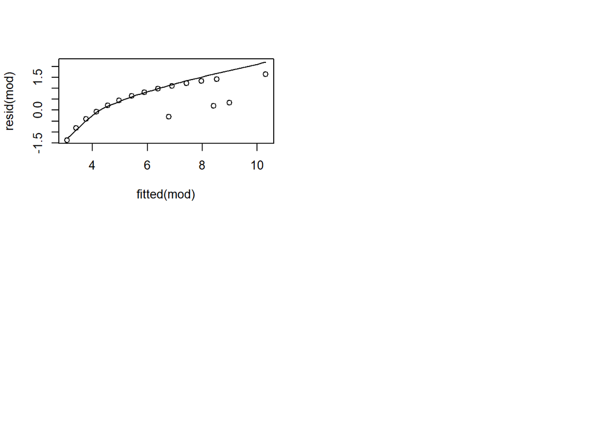

```r
# Create a scatter plot of fitted values vs. residuals, checking for any patterns
scatter.smooth(fitted(mod), resid(mod))
# The plot appears to be okay based on this check

# Before drawing conclusions, the linear predictors need to be transformed.
# Since a log-link function was used, we need to use the "exp" function for transformation.
# Refer to Korner-Nievergel et al. (2015). Bayesian Data Analysis in Ecology Using Linear Models with R, BUGS, and Stan (1st edition). Academic Press, page 149 for details on this transformation.
```

##Drawing conclusions

```r
set.seed(123)
# Set the number of simulations
nsim <- 10000

# Simulate data based on the mixed-effects Poisson regression model (mod)
bsim <- sim(mod, n.sim = nsim)

# Display the structure of the simulated data
str(bsim)
```

```
## Formal class 'sim.merMod' [package "arm"] with 3 slots
##   ..@ fixef: num [1:10000, 1:2] 0.585 0.634 1.006 1.127 0.842 ...
##   .. ..- attr(*, "dimnames")=List of 2
##   .. .. ..$ : NULL
##   .. .. ..$ : chr [1:2] "(Intercept)" "no_mates"
##   ..@ ranef:List of 2
##   .. ..$ random_factor: num [1:10000, 1:102, 1] -0.2825 -0.0763 0.049 -0.0017 0.6301 ...
##   .. .. ..- attr(*, "dimnames")=List of 3
##   .. .. .. ..$ : NULL
##   .. .. .. ..$ : chr [1:102] "1" "2" "3" "4" ...
##   .. .. .. ..$ : chr "(Intercept)"
##   .. ..$ lab_id       : num [1:10000, 1:83, 1] 0 0 0 0 0 0 0 0 0 0 ...
##   .. .. ..- attr(*, "dimnames")=List of 3
##   .. .. .. ..$ : NULL
##   .. .. .. ..$ : chr [1:83] "CM05_037" "CM05_051" "CM05_067" "CM05_072" ...
##   .. .. .. ..$ : chr "(Intercept)"
##   ..@ sigma: logi NA
```

```r
# Use the log-link function, so we need to use exp to get the natural values
# Calculate and print quantiles of fixed effects
round(apply(bsim@fixef, 2, quantile, prob = c(0.025, 0.5, 0.975)), 2)
```

```
##       (Intercept) no_mates
## 2.5%         0.39     0.18
## 50%          0.85     0.59
## 97.5%        1.32     1.00
```

```r
#round(apply(bsim@ranef$random_factor, 2, quantile, prob = c(0.025, 0.5, 0.975)), 2)
```

```r
# Calculate the proportion of simulated fixed effects > 0 for each parameter
# Print the results
round(sum(fixef(bsim)[, 1] > 0) / nsim, 5)  #
```

```
## [1] 0.9998
```

```r
round(sum(fixef(bsim)[, 2] > 0) / nsim, 5)  #
```

```
## [1] 0.9975
```

```r
#Calculate the quantiles (2.5%, 50%, and 97.5%) for the entire random effect distribution,
round(quantile(as.vector(bsim@ranef$random_factor), prob = c(0.025, 0.5, 0.975)),2)
```

```
##  2.5%   50% 97.5%
## -0.79  0.00  0.89
```

```r
round(quantile(as.vector(bsim@ranef$lab_id), prob = c(0.025, 0.5, 0.975)),2)
```

```
##  2.5%   50% 97.5%
##     0     0     0
```

```r
# Proportion of values greater than 0 for random effects
sum(as.vector(bsim@ranef$random_factor) > 0) / length(as.vector(bsim@ranef$random_factor))
```

```
## [1] 0.5041794
```

```r
sum(as.vector(bsim@ranef$lab_id) > 0) / length(as.vector(bsim@ranef$lab_id))
```

```
## [1] 0
```

#Table S2a

```r
# --- 1. Quantiles for fixed effects ---
qtab <- round(apply(bsim@fixef, 2, quantile, prob = c(0.025, 0.5, 0.975)), 2)

# --- 2. Posterior probability > 0 ---
prop_gt0 <- round(apply(fixef(bsim), 2, function(x) mean(x > 0)), 3)

# --- 3. Combine into a data frame ---
result_table <- as.data.frame(t(qtab)) %>%
  mutate(`P(β > 0)` = prop_gt0) %>%
  rownames_to_column(var = "Effect") %>%
  mutate(`β (95% Crl)` = paste0(`50%`, " (", `2.5%`, ", ", `97.5%`, ")")) %>%
  select(Effect, `β (95% Crl)`, `P(β > 0)`)

# --- 4. Rename fixed effects ---
result_table$Effect <- recode(result_table$Effect,
  "(Intercept)" = "Intercept: females",
  "no_mates" = "Mating success"
)

# --- 5. Add random effects: observation level and identity  ---
obslevel_quant <- round(quantile(as.vector(bsim@ranef$random_factor), prob = c(0.025, 0.5, 0.975)), 2)
obslevel_prop <- round(sum(as.vector(bsim@ranef$random_factor) > 0) / length(as.vector(bsim@ranef$random_factor)), 3)

id_quant <- round(quantile(as.vector(bsim@ranef$lab_id), prob = c(0.025, 0.5, 0.975)), 2)
id_prop <- round(sum(as.vector(bsim@ranef$lab_id) > 0) / length(as.vector(bsim@ranef$lab_id)), 3)

obslevel_row <- data.frame(
  Effect = "Random effect: observation level 102 groups",
  `β (95% Crl)` = paste0(obslevel_quant["50%"], " (", obslevel_quant["2.5%"], ", ", obslevel_quant["97.5%"], ")"),
  `P(β > 0)` = obslevel_prop,
  check.names = FALSE
)

id_row <- data.frame(
  Effect = "Random effect: bird identity 83 groups",
  `β (95% Crl)` = paste0(id_quant["50%"], " (", id_quant["2.5%"], ", ", id_quant["97.5%"], ")"),
  `P(β > 0)` = id_prop,
  check.names = FALSE
)

result_table <- bind_rows(result_table, obslevel_row, id_row)

# --- 6. R² values for lognormal model ---
r2_log <- MuMIn::r.squaredGLMM(mod)[1, ]
```

```
## boundary (singular) fit: see help('isSingular')
```

```r
r2_text <- paste0("R²m = ", round(r2_log["R2m"], 3), ", R²c = ", round(r2_log["R2c"], 3))

# --- 6a. Extract number of observations and the number of groups of random effect ---
n_obs <- nobs(mod)

# --- 7. Render gt table with bold random effect row ---
tab <- result_table %>%
  gt() %>%
  tab_header(
    title = "a) Absolute values: female white browed coucals",
    subtitle = paste0("Reproductive success\nN = ", n_obs, " obs. of 83 ind.\n", r2_text)
  ) %>%
  cols_label(
    `β (95% Crl)` = "β (95% Crl)",
    `P(β > 0)` = "P(β) > 0"
  )  %>%
  # Align all columns to the left
  cols_align(
    align = "left",
    columns = everything()
  ) %>%
  # Align column labels and table to the left
  tab_options(
    table.align = "left"

  )

# --- 8. Show table ---
tab
```

a) Absolute values: female white browed coucals

Reproductive success N = 102 obs. of 83 ind. R²m = 0.059, R²c = 0.463

| Effect | β (95% Crl) | P(β) > 0 |
| --- | --- | --- |
| Intercept: females | 0.85 (0.39, 1.32) | 1.000 |
| Mating success | 0.59 (0.18, 1) | 0.998 |
| Random effect: observation level 102 groups | 0 (-0.79, 0.89) | 0.504 |
| Random effect: bird identity 83 groups | 0 (0, 0) | 0.000 |

```r
#save the table:
gtsave(tab, "supl/TableS2a_WBC.pdf")
```

```
## file:///C:/Users/lguadal/AppData/Local/Temp/RtmpSQe5fg/file4a3047e7450b.html screenshot completed
```

# Fig 2c: Posterior distribution of absolute slope

```r
#extracting the posterior draws of the slopes
slope_females <- bsim@fixef[, "no_mates"]



# posterior summaries
summarize_slope <- function(slope_draws) {
  mean_val <- mean(slope_draws)
  ci <- quantile(slope_draws, probs = c(0.025, 0.975))
  p_gt0 <- mean(slope_draws > 0)
  c(mean = mean_val, lwr = ci[1], upr = ci[2], p_gt0 = p_gt0)
}

summary_females <- summarize_slope(slope_females)


summary_females
```

```
##      mean  lwr.2.5% upr.97.5%     p_gt0
## 0.5929109 0.1815005 0.9968943 0.9975000
```

```r
# summaries for each group (mean, lwr, upr)
summaries <- data.frame(
  group = c("Females"),
  rbind(summary_females),
  row.names = NULL
)

# compute densities for each slope
dens_list <- list(
  Females = density(slope_females)
)

# build density dataframe and add summaries
dens_df <- do.call(rbind, lapply(names(dens_list), function(gr) {
  d <- dens_list[[gr]]
  s <- summaries[summaries$group == gr, ]
  data.frame(x = d$x,
             y = d$y,
             group = gr,
             mean = s$mean,
             lwr = s$lwr,
             upr = s$upr)
}))

# compute density mode (x where density is maximized, and its y height)
modes <- dens_df %>%
  group_by(group) %>%
  slice_max(y, n = 1, with_ties = FALSE) %>%
  select(group, mode_x = x, mode_y = y)
```

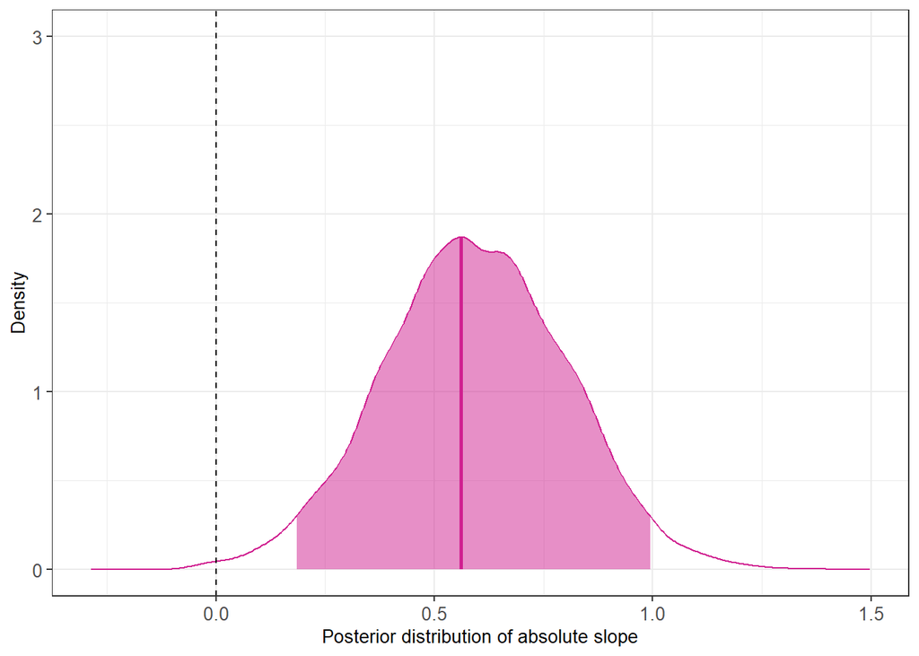

```r
# plot
estimates_bateman <- ggplot(dens_df, aes(x = x, y = y, color = group)) +
  # ribbon between lwr and upr
  geom_ribbon(aes(ymin = 0, ymax = ifelse(x >= lwr & x <= upr, y, NA),
                  fill = group),
              alpha = 0.5, color = NA) +
  # full density outline
  geom_line(size = 0.5) +
  # short vertical line at mode (only up to the peak of the density)
  geom_segment(aes(x = mode_x, xend = mode_x,
                   y = 0, yend = mode_y,
                   color = group),
               data = modes, linetype = "solid", size =1) +
  # reference at 0
  geom_vline(xintercept = 0, linetype = "dashed") +
  labs(x = "Posterior distribution of absolute slope", y = "Density") +
   scale_color_manual(values = c("violetred")) +
  scale_fill_manual(values = c("violetred")) +
  scale_x_continuous(breaks = seq(floor(min(dens_df$x)),
                                  ceiling(max(dens_df$x)),
                                  by = 0.5)) +
custom_theme+
  theme(legend.position="none")  +
  ylim(0, 3)
estimates_bateman
```

## Fitting the model

```r
# Display the head of the 'dataclean' dataframe
head(dataclean)
```

|  | lab_id | year | no_off | no_mates | sex | random_factor | ring_no |
| --- | --- | --- | --- | --- | --- | --- | --- |
| 1 | CM05_037 | 2005 | 3 | 1 | female | 1 | GN 44454 |
| 2 | CM05_051 | 2005 | 4 | 1 | female | 2 | GN 44462 |
| 3 | CM05_067 | 2005 | 6 | 1 | female | 3 | NA |
| 4 | CM05_072 | 2005 | 2 | 1 | female | 4 | GN 44483 |
| 5 | CM05_117 | 2005 | 4 | 1 | female | 5 | GN 52387 |
| 6 | CW13_046 | 2006 | 2 | 1 | female | 6 | NA |

```r
# Calculate the range of values for the 'no_mates' variable in 'dataclean'
range_nomates <- range(dataclean$no_mates, na.rm = TRUE)

# Display the range of 'no_mates'
range_nomates
```

```
## [1] 1 2
```

```r
# Create a new dataframe 'newdat' with a grid of values for 'no_mates' and 'sex'
newdat <- expand.grid(no_mates = seq(1, 2, length = 100),
                      sex = levels(dataclean$sex))

# Display the frequency table of the 'sex' variable in 'newdat'
table(newdat$sex)
```

```
##
## female   male
##    100    100
```

```r
# Display the head of the 'newdat' dataframe
head(newdat)
```

|  | no_mates | sex |
| --- | --- | --- |
| 1 | 1.000000 | female |
| 2 | 1.010101 | female |
| 3 | 1.020202 | female |
| 4 | 1.030303 | female |
| 5 | 1.040404 | female |
| 6 | 1.050505 | female |

```r
# Create a model matrix 'Xmat' for the predictor variable 'no_mates' in 'newdat'
Xmat <- model.matrix(~ no_mates, data = newdat)

# Create an empty matrix 'fitmat' to store simulation results
fitmat <- matrix(ncol = nsim, nrow = nrow(newdat))

# Perform simulations and store results in 'fitmat'
for (i in 1:nsim) fitmat[, i] <- exp(Xmat %*% bsim@fixef[i,])

# Calculate lower and upper quantiles for the simulated results
newdat$lwr <- apply(fitmat, 1, quantile, prob = 0.025)
newdat$upr <- apply(fitmat, 1, quantile, prob = 0.975)

# Calculate the fitted values using the fixed effects from the model
newdat$fit <- exp(Xmat %*% fixef(mod))

# Display the final 'newdat' dataframe with simulation results
head(newdat)
```

|  | no_mates | sex | lwr | upr | fit |
| --- | --- | --- | --- | --- | --- |
| 1 | 1.000000 | female | 3.739566 | 4.816823 | 4.240502 |
| 2 | 1.010101 | female | 3.766471 | 4.841673 | 4.265946 |
| 3 | 1.020202 | female | 3.794139 | 4.863313 | 4.291542 |
| 4 | 1.030303 | female | 3.821238 | 4.889269 | 4.317292 |
| 5 | 1.040404 | female | 3.850261 | 4.916791 | 4.343197 |
| 6 | 1.050505 | female | 3.876796 | 4.941505 | 4.369257 |

## Create the scatterplot seperately

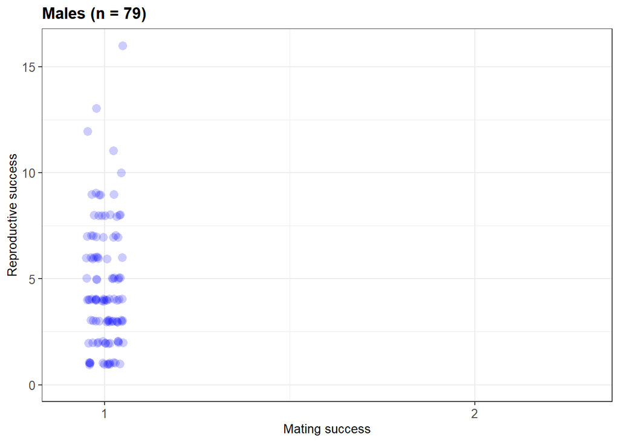

```r
# Filter data for males only
males_data <- subset(dataclean, sex == "male")

# Plotting for males only
males <- ggplot(males_data, aes(x = no_mates, y = no_off)) +
  geom_point(alpha = 0.2, size = 3, position = position_jitter(width = 0.05, height = 0.06), color = "blue" , shape = 16) +
  labs(title = "Males (n = 79) ")+
  labs(x = "Mating success", y = "Reproductive success") +
  scale_x_continuous(breaks = c(1, 2), limits = c(0.90, 2.3)) +
custom_theme +
  ylim(0, 16) +
  guides(shape = FALSE)

males
```

## Create the scatterplot for females

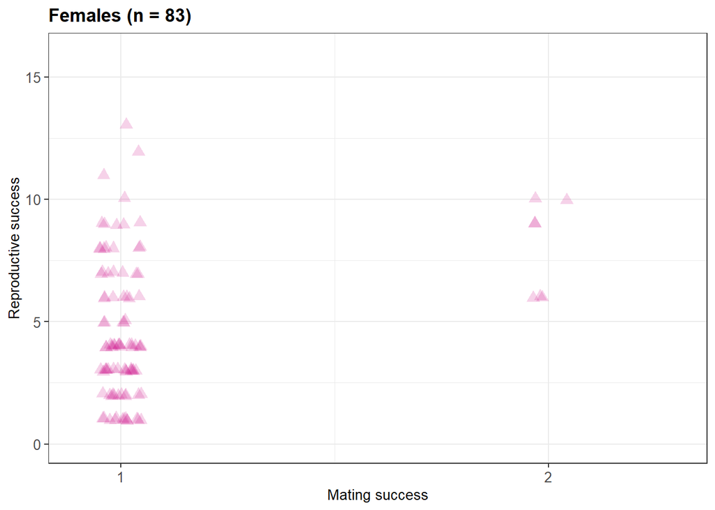

```r
# Scatterplot with points colored and shaped by sex, and slight jitter for better visibility
plot <- ggplot(subset(dataclean, sex == "female"), aes(x = no_mates, y = no_off)) +
  geom_point(alpha = 0.2, size = 3, shape=17, position = position_jitter(width = 0.05, height = 0.06), color = "violetred")+
   labs(x = "Mating success", y = "Reproductive success",
       color = "Sex", shape = "Sex") +
  labs(title = "Females (n = 83) ")+
  scale_x_continuous(breaks = c(1, 2), limits = c(0.90, 2.3)) +
  scale_shape_manual(values = c(17, 16)) +
custom_theme +
  ylim(0, 16) +
  guides(shape = FALSE)

# Display the first version of the plot
print(plot)
```

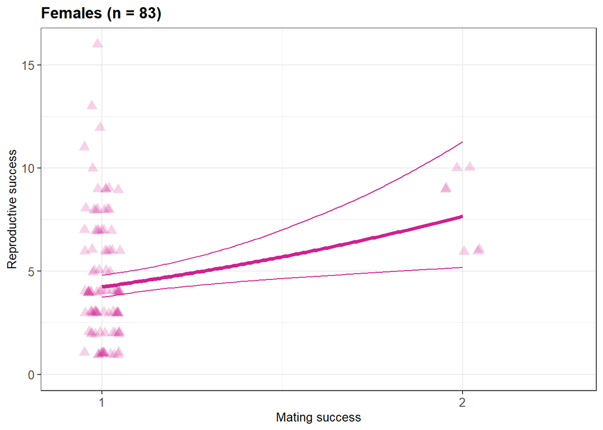

```r
# Add lines to the scatterplot
index <- newdat$sex == "female"
females <- plot +
  geom_line(data = newdat[index & newdat$no_mates <= 2 & newdat$no_mates >= 1,], aes(x = no_mates, y = fit), color =
"violetred", size = 1.5) +
  geom_line(data = newdat[index & newdat$no_mates <= 2 & newdat$no_mates >= 1, ], aes(x = no_mates, y = lwr), linetype = "solid", color =
"violetred") +
  geom_line(data = newdat[index & newdat$no_mates <= 2 & newdat$no_mates >= 1,], aes(x = no_mates, y = upr), linetype = "solid", color =
"violetred")

# Save the plot with added lines as an image
females
```